# pilot

REACH BGD

2 July 2019

# Severity Scoring Pilot Host Community

## Summary

### Results by Union

Distribution of severity:

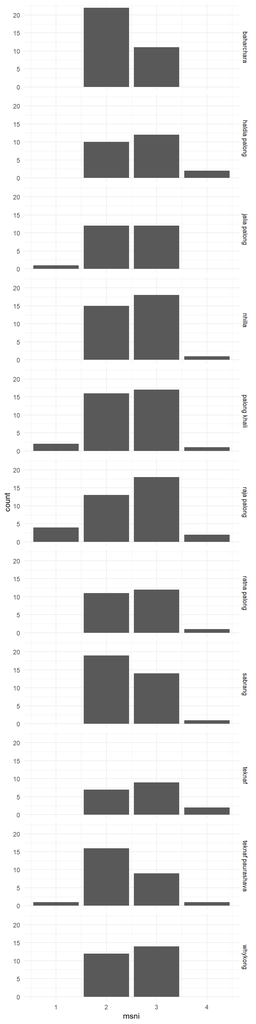

```r
faceted_density_plot(assessment$data,
                     x_variable_name = "msni",
                     default_disaggregation)
```

The estimated severity in the host community:

```r
type_of_analysis<-map_to_case("group_difference",
                  dependent.var.type = "categorical",
                  independent.var.type = "categorical")


severity_disaggregated <- map_to_result(data,dependent.var = "msni",
                                        independent.var = default_disaggregation,
                                        case = type_of_analysis,
                                        weighting = weighting)

severity_disaggregated %>%
  map_to_labeled(questionnaire) %>%
  map_to_table %>% kable %>% kable_styling()
```

| Subset | 1 | 2 | 3 | 4 |
| --- | --- | --- | --- | --- |
| Baharchara | 0% | 67% (51%-83%) | 33% (17%-49%) | 0% |
| haldia palong | 0% | 42% (22%-61%) | 50% (30%-70%) | 8% (0%-19%) |
| jalia palong | 4% (0%-12%) | 48% (28%-68%) | 48% (28%-68%) | 0% |
| Nhilla | 0% | 44% (27%-61%) | 53% (36%-70%) | 3% (0%-9%) |
| palong khali | 6% (0%-13%) | 44% (28%-61%) | 47% (31%-64%) | 3% (0%-8%) |
| raja palong | 11% (1%-21%) | 35% (20%-51%) | 49% (33%-65%) | 5% (0%-13%) |
| ratna palong | 0% | 46% (26%-66%) | 50% (30%-70%) | 4% (0%-12%) |
| Sabrang | 0% | 56% (39%-73%) | 41% (25%-58%) | 3% (0%-9%) |
| teknaf paurashava | 4% (0%-11%) | 59% (41%-78%) | 33% (16%-51%) | 4% (0%-11%) |
| Teknaf Sadar | 0% | 39% (16%-61%) | 50% (27%-73%) | 11% (0%-26%) |
| Whykong | 0% | 46% (27%-65%) | 54% (35%-73%) | 0% |

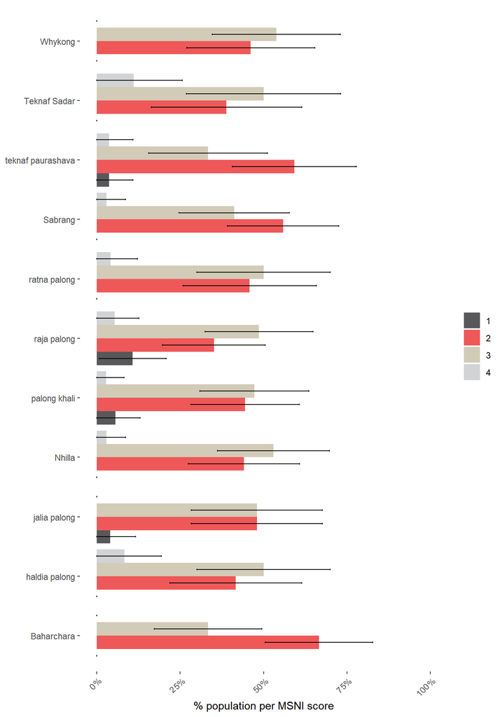

```r
severity_disaggregated %>%
  (function(x){x$summary.statistic<-x$summary.statistic %>% arrange(independent.var.value,numbers);x}) %>%
  map_to_labeled(questionnaire) %>% (hypegrammaR:::grouped_barchart_percent) %>% .$ggplot + coord_flip()+ylab("% population per MSNI score")
```

### Distribution - How ‘varied’ are the scores?

```r
design<-map_to_design(data,weighting_function =  weighting)
standard_deviation <- sqrt(survey::svyvar(~msni,design)[1])
```

[figure not shown]

```r
ecdf <- weighted_ecdf(data$msni, weighting(data))

ggplot(ecdf, aes(x, cum.pct)) +
  geom_line() +
  theme_minimal() +
  ylab("Cummulative probability") +
  xlab("Score")
```

## Sensitivity and Robustness

Missing values in composite indicators

```r
percent_na_sev<-severity[,-1] %>% lapply(percent_na) %>% unlist
data.frame(`composite variable` = names(severity[,-1]),
           `percent NA` = percent_na_sev,
           check.names = FALSE) %>%
  kable %>%
  kable_styling()
```

|  | composite variable | percent NA |
| --- | --- | --- |
| si.fsl.fcs | si.fsl.fcs | 0.278 % |
| si.fsl.unsustainable_food | si.fsl.unsustainable_food | 0 % |
| si.fsl.main_income | si.fsl.main_income | 0.104 % |
| si.fsl.food_exp | si.fsl.food_exp | 0.347 % |
| si.protection.feel_safe | si.protection.feel_safe | 0.868 % |
| si.shelter.nfi.exp | si.shelter.nfi.exp | 0.347 % |
| si.shelter.exp | si.shelter.exp | 0.347 % |
| si.shelter.topo | si.shelter.topo | 0.278 % |
| si.shelter.essential | si.shelter.essential | 0 % |
| si.wash.improved_water_access | si.wash.improved_water_access | 0.625 % |
| si.wash.defecation | si.wash.defecation | 0 % |
| si.wash.enough_water | si.wash.enough_water | 0 % |
| si.wash.soap | si.wash.soap | 0 % |
| si.wash.visible_feces | si.wash.visible_feces | 0 % |
| si.wash.total_water_coll_time | si.wash.total_water_coll_time | 0.278 % |
| si.health.preg | si.health.preg | 0 % |
| si.health.health_worker | si.health.health_worker | 0 % |
| si.edu.materials | si.edu.materials | 0 % |
| si.capacity_gap.rcsi | si.capacity_gap.rcsi | 0.278 % |
| si.health.mosq | si.health.mosq | 0 % |
| si.health.indiv_illness | si.health.indiv_illness | 0 % |
| si.protection.missing_child | si.protection.missing_child | 0 % |
| si.health.birthplace | si.health.birthplace | 0 % |
| si.health.dia | si.health.dia | 0 % |
| si.capacity_gap.child_lab_bad | si.capacity_gap.child_lab_bad | 0 % |
| si.health.disability_tr | si.health.disability_tr | 0 % |
| si.edu.formal_learn_space | si.edu.formal_learn_space | 0 % |
| si.edu.non_formal_learn_space | si.edu.non_formal_learn_space | 0 % |
| si.fsl.individual_worked | si.fsl.individual_worked | 0 % |
| capacity | capacity | 0.278 % |
| edu | edu | 0 % |
| fsl | fsl | 0.451 % |
| health | health | 88.65 % |
| protection | protection | 0.868 % |
| shelter | shelter | 0.347 % |
| wash | wash | 0.902 % |
| impact | impact | 0 % |

### Sensitivity to Included Indicators

```r
# create variations and calculate msni
msni_varied_indicators<-msni_variations(combination_tables,
                                        assessment$severity,
                                        variation_function = vary_combination_tables_indicator_inclusion)
```

We test how sensitive the index is with regards to which indicators are included; The overall score should ideally not be completely changed if specific indicators are added or removed; at the same time we should expect at least some variation based on which indicators are included. Prior to analysis, we choose a threshold of **a difference of 0.5 on the 1-4 scale that should ideally not be surpassed** if an individual indicator is removed (or added). We recalculate the score after removing each of the 27 sub-indicators , and test for each one whether the difference to the complete index exceeds 0.5

```r
# t-test: differences smaller 0.5 on average?

# new dataframe: differences & stratum

msni_original<- tibble(msni = assessment$data$msni)


sensitivity_test_table<- sensitivity_variation_test_result_table(msni_original = msni_original,
                                        msni_varied = msni_varied_indicators,
                                        threshold = 0.5,
                                        strata_data_name = default_disaggregation,
                                        strata_data_values = data[[default_disaggregation]])

sensitivity_test_table %>% kable(escape = FALSE) %>% kable_styling()
```

| Indicator | average absolute difference from original msni index | p value (Bonferroni corrected) | Difference signifcantly smaller than threshold (at p<=0.01) |
| --- | --- | --- | --- |
| protection missing_child | 0.3045957 | 0 | Yes |
| capacity_gap child_lab_bad | 0.2755718 | 0 | Yes |
| fsl individual_worked | 0.2538653 | 0 | Yes |
| capacity_gap rcsi | 0.2140601 | 0 | Yes |
| fsl fcs | 0.1283543 | 0 | Yes |
| fsl unsustainable_food | 0.1279187 | 0 | Yes |
| fsl main_income | 0.1243866 | 0 | Yes |
| shelter topo | 0.1190866 | 0 | Yes |
| health dia | 0.1162292 | 0 | Yes |
| fsl food_exp | 0.1157208 | 0 | Yes |
| shelter essential | 0.0654078 | 0 | Yes |
| health indiv_illness | 0.0427320 | 0 | Yes |
| wash defecation | 0.0389247 | 0 | Yes |
| shelter exp | 0.0308624 | 0 | Yes |
| health health_worker | 0.0297497 | 0 | Yes |
| shelter nfi exp | 0.0267603 | 0 | Yes |
| wash enough_water | 0.0201483 | 0 | Yes |
| protection feel_safe | 0.0147975 | 0 | Yes |
| health preg | 0.0139165 | 0 | Yes |
| health mosq | 0.0139165 | 0 | Yes |
| wash improved_water_access | 0.0070703 | 0 | Yes |
| wash soap | 0.0065925 | 0 | Yes |
| wash total_water_coll_time | 0.0045087 | 0 | Yes |
| edu formal_learn_space | 0.0040968 | 0 | Yes |
| edu non_formal_learn_space | 0.0040968 | 0 | Yes |
| health birthplace | 0.0000000 | 0 | Yes |
| wash visible_feces | 0.0000000 | 0 | Yes |

The index is robust towards all other indicators within the threshold of 0.5 points on the scale.

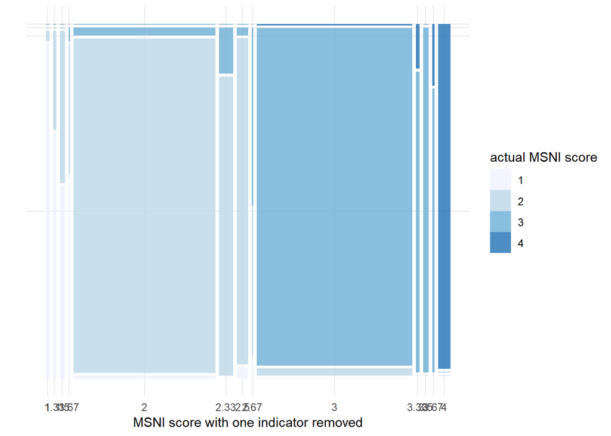

```r
# Example of how the formula is built
#
#     weight = 1
#     x = product(Y, X)
#     fill = W
#     conds = product(Z)
#
# These aesthetics set up the formula for the distribution:
#
#     Formula: 1 ~ W + X + Y | Z

stratum_tibble<-tibble(stratum=assessment$data[[default_disaggregation]])
colnames(stratum_tibble)<-default_disaggregation
msni_varied_and_original<-c(msni_varied_indicators,
                            msni_original,
                            stratum_tibble) %>% as_tibble

msni_varied_and_original<-gather_(msni_varied_and_original,key = "key",value = 'value',gather_cols = names(msni_varied_and_original)[!(names(msni_varied_and_original) %in% c("msni",default_disaggregation))])
msni_varied_and_original$weights<-weighting(msni_varied_and_original)
msni_varied_and_original$value<-round(msni_varied_and_original$value,2)
msni_varied_and_original<-msni_varied_and_original[!is.na(msni_varied_and_original),]
ggplot(msni_varied_and_original)+
  geom_mosaic(aes(weight=weights,
                  x=product(msni,value),fill = (msni)))+scale_fill_brewer(name = "actual MSNI score")+theme_minimal()+theme(axis.text.y = element_blank())+xlab("MSNI score with one indicator removed")+ylab("")
```

### Sensitivity to Thresholds

The methodology relies heavily on normative judgement from sector as well is inter-sectoral experts. As such, it needs to be robust with regards to variations in those judgements. We add random noise of varying strength to the expert decision of how the indicators are combined, and compare the results to the original msni needs score.

```r
# create variations and calculate msni
msni_varied_thresholds<-msni_variations(combination_tables,
                                        assessment$severity,
                                        variation_function = vary_combination_tables_thresholds)
```

```r
# t-test: differences smaller 0.5 on average?

# new dataframe: differences & stratum

msni_original<- tibble(msni = assessment$data$msni)


sensitivity_test_table<- sensitivity_variation_test_result_table(msni_original = msni_original,
                                        msni_varied = msni_varied_thresholds,
                                        threshold = 0.5,
                                        strata_data_name = default_disaggregation,
                                        strata_data_values = data[[default_disaggregation]])

sensitivity_test_table %>% kable(escape = FALSE) %>% kable_styling()
```

| Indicator | average absolute difference from original msni index | p value (Bonferroni corrected) | Difference signifcantly smaller than threshold (at p<=0.01) |
| --- | --- | --- | --- |
| V4 | 0.5274075 | 25.10886 | No |
| V5 | 0.5274075 | 25.10886 | No |
| V6 | 0.5274075 | 25.10886 | No |
| V8 | 0.5274075 | 25.10886 | No |
| V10 | 0.5274075 | 25.10886 | No |
| shelter | 0.4097031 | 0.16175 | No |
| V53 | 0.4097031 | 0.16175 | No |
| V56 | 0.4097031 | 0.16175 | No |
| V57 | 0.4097031 | 0.16175 | No |
| V60 | 0.4097031 | 0.16175 | No |
| V22 | 0.3387185 | 0.00000 | Yes |
| V23 | 0.3387185 | 0.00000 | Yes |
| V25 | 0.3387185 | 0.00000 | Yes |
| V27 | 0.3387185 | 0.00000 | Yes |
| V28 | 0.3387185 | 0.00000 | Yes |
| V29 | 0.3387185 | 0.00000 | Yes |
| V30 | 0.3387185 | 0.00000 | Yes |
| V34 | 0.3188565 | 0.00000 | Yes |
| V35 | 0.3188565 | 0.00000 | Yes |
| V36 | 0.3188565 | 0.00000 | Yes |
| V38 | 0.3188565 | 0.00000 | Yes |
| V40 | 0.3188565 | 0.00000 | Yes |
| capacity | 0.1993625 | 0.00000 | Yes |
| V2 | 0.1993625 | 0.00000 | Yes |
| V3 | 0.1993625 | 0.00000 | Yes |
| V7 | 0.1993625 | 0.00000 | Yes |
| V9 | 0.1993625 | 0.00000 | Yes |
| fsl | 0.1142657 | 0.00000 | Yes |
| V24 | 0.1142657 | 0.00000 | Yes |
| V26 | 0.1142657 | 0.00000 | Yes |
| V62 | 0.1139892 | 0.00000 | Yes |
| V63 | 0.1139892 | 0.00000 | Yes |
| V64 | 0.1139892 | 0.00000 | Yes |
| V65 | 0.1139892 | 0.00000 | Yes |
| V68 | 0.1139892 | 0.00000 | Yes |
| V69 | 0.1139892 | 0.00000 | Yes |
| protection | 0.0897935 | 0.00000 | Yes |
| V43 | 0.0897935 | 0.00000 | Yes |
| V44 | 0.0897935 | 0.00000 | Yes |
| V46 | 0.0897935 | 0.00000 | Yes |
| V48 | 0.0897935 | 0.00000 | Yes |
| V52 | 0.0856951 | 0.00000 | Yes |
| V54 | 0.0856951 | 0.00000 | Yes |
| V55 | 0.0856951 | 0.00000 | Yes |
| V58 | 0.0856951 | 0.00000 | Yes |
| V59 | 0.0856951 | 0.00000 | Yes |
| health | 0.0440809 | 0.00000 | Yes |
| V32 | 0.0440809 | 0.00000 | Yes |
| V33 | 0.0440809 | 0.00000 | Yes |
| V37 | 0.0440809 | 0.00000 | Yes |
| V39 | 0.0440809 | 0.00000 | Yes |
| wash | 0.0084986 | 0.00000 | Yes |
| V66 | 0.0084986 | 0.00000 | Yes |
| V67 | 0.0084986 | 0.00000 | Yes |
| V70 | 0.0084986 | 0.00000 | Yes |
| V42 | 0.0052908 | 0.00000 | Yes |
| V45 | 0.0052908 | 0.00000 | Yes |
| V47 | 0.0052908 | 0.00000 | Yes |
| V49 | 0.0052908 | 0.00000 | Yes |
| V50 | 0.0052908 | 0.00000 | Yes |
| V14 | 0.0040968 | 0.00000 | Yes |
| V15 | 0.0040968 | 0.00000 | Yes |
| V16 | 0.0040968 | 0.00000 | Yes |
| V17 | 0.0040968 | 0.00000 | Yes |
| V19 | 0.0040968 | 0.00000 | Yes |
| edu | 0.0000000 | 0.00000 | Yes |
| V12 | 0.0000000 | 0.00000 | Yes |
| V13 | 0.0000000 | 0.00000 | Yes |
| V18 | 0.0000000 | 0.00000 | Yes |
| V20 | 0.0000000 | 0.00000 | Yes |

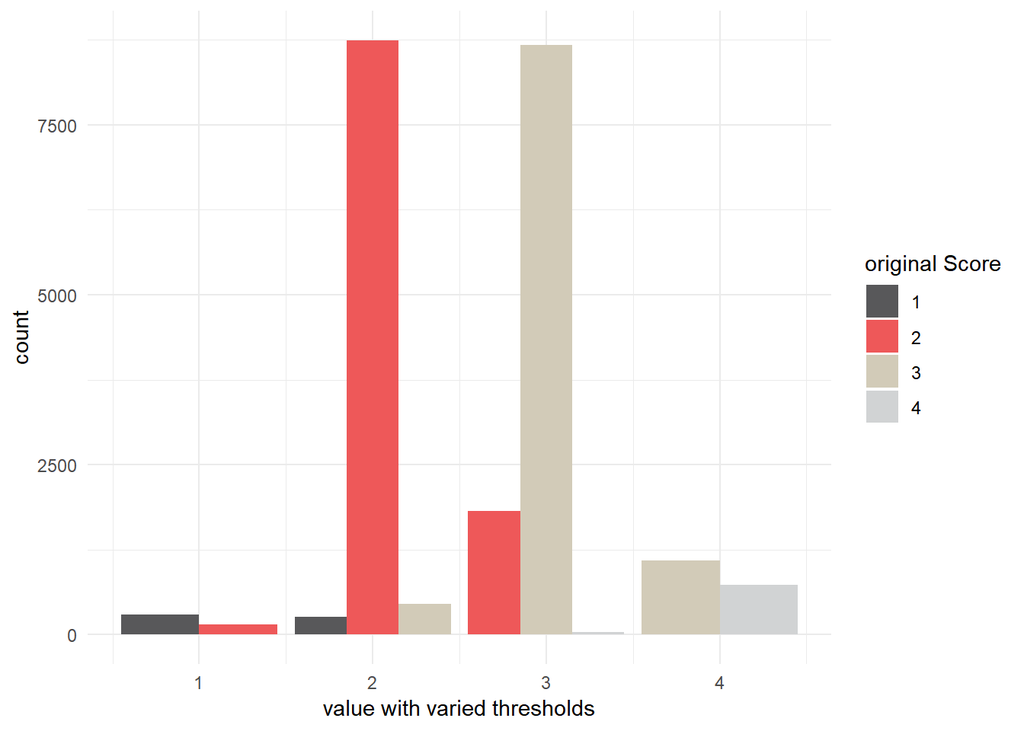

```r
msni_varied_thresholds_with_original<-msni_varied_thresholds
msni_varied_thresholds_with_original$original<-assessment$data$msni

msni_varied_thresholds_long <- msni_varied_thresholds_with_original %>% gather("key","value", -original)
msni_varied_thresholds_long$key<-gsub("\\.","",msni_varied_thresholds_long$key) %>% gsub("[0-9]","",.)
ggplot(msni_varied_thresholds_long)+geom_bar(aes(x = value,fill = factor(original)),position = "dodge")+xlab("value with varied thresholds")+hypegrammaR:::scale_fill_reach_categorical(4,name = "original Score")+theme_minimal()
```